# Final Project Report

November 28, 2019

## Motivation and Application

Our choice of project was motivated by an example problem from class and a homework problem that we were assigned. The example problem involved fitting a logistic regression model to historical daily S&P 500 stock index data with the goal of predicting whether the stock market would go up or down. The homework problem was similar, but it involved predicting whether the S&P 500 would go up or down on a weekly rather than daily basis. Most of the potential predictors for both of these models were percentage returns of several previous days or weeks. We found these problems interesting and so we decided to extend the concept. We conducted a statistical analysis wherein we utilized several supervised learning methods to predict weekly Nasdaq Composite Index returns. We used regression methods to predict weekly percentage returns and classification methods to predict whether the Nasdaq would go up or down over a given week. The set of predictors included the percentage returns and percent changes in trading volume from the previous three weeks.

This analysis could be applicable to stock traders who buy and sell stocks on a short-term basis. If the statistical models were able to accurately predict the return and/or direction of the Nasdaq in the succeeding week, then a trader could buy or sell a Nasdaq Composite Index exchange-traded fund (ETF) based on the prediction. For example, if the models were run immediately after market close on a Friday and they predicted the Nasdaq to have a positive return over the next week, then a trader could purchase the Nasdaq ETF in after-hours. Alternatively, if the models predicted a negative return over the subsequent week, then a trader could sell the Nasdaq ETF in after-hours. For this to be a profitable strategy, the ETF would have to be purchased or sold at a price very close to or more favorable than the Friday closing price.

## Data

Weekly Nasdaq Composite Index data was downloaded from Yahoo! Finance for the time period from 11/26/2001 to 11/25/2019. Each row in the dataset contained prices and trading volume for a given week. The relevant columns for our analysis were ‘Close’, which contained the weekly closing price, and ‘Volume’, which contained the weekly trading volume. Several new columns had to be derived before we could apply statistical learning methods. A new column named ‘Return’ was created and populated with the weekly close-to-close-price percentage returns. Another column called ‘Vol_change’ was created and populated with the week-to-week percent change in trading volume. Also, a ‘Direction’ binary variable was derived that took the value ‘Down’ if the ‘Return’ was less than 0 and the value ‘Up’ otherwise. Finally, lag columns were added that contained the percentage returns and volume changes for the three preceding weeks. Once the data preparation was completed (all of which was done in R), the finalized data was written to a CSV file.

The CSV file is read into a data frame.

```r
nasdaq = read.csv('Nasdaq Prices Final.csv')
head(nasdaq)
```

```
##         Date    Open    High     Low   Close     Volume     Return
## 1 2001-12-24 1946.84 2002.72 1942.07 1987.26 4261080000  2.1291714
## 2 2001-12-31 1984.31 2077.89 1936.56 2059.38 7347750000  3.6291111
## 3 2002-01-07 2075.24 2098.88 2018.68 2022.46 9703400000 -1.7927689
## 4 2002-01-14 2012.59 2018.42 1922.70 1930.34 8980190000 -4.5548489
## 5 2002-01-21 1946.87 1959.93 1879.24 1937.70 7251520000  0.3812792
## 6 2002-01-28 1951.12 1959.05 1851.49 1911.24 8937960000 -1.3655345
##   Vol_change Direction       Lag1       Lag2       Lag3   Vol_Lag1
## 1 -57.455442        Up -0.3758038 -3.3686891  4.6970370   5.031141
## 2  72.438678        Up  2.1291714 -0.3758038 -3.3686891 -57.455442
## 3  32.059474      Down  3.6291111  2.1291714 -0.3758038  72.438678
## 4  -7.453161      Down -1.7927689  3.6291111  2.1291714  32.059474
## 5 -19.249815        Up -4.5548489 -1.7927689  3.6291111  -7.453161
## 6  23.256366      Down  0.3812792 -4.5548489 -1.7927689 -19.249815
##     Vol_Lag2   Vol_Lag3
## 1  -7.527773  31.673719
## 2   5.031141  -7.527773
## 3 -57.455442   5.031141
## 4  72.438678 -57.455442
## 5  32.059474  72.438678
## 6  -7.453161  32.059474
```

```r
attach(nasdaq)
```

The relevant variables for this analysis are:

*Return* - Percentage return for the week (computed from closing prices for this week and the previous week)

*Direction* - A categorical variable indicating whether the Nasdaq went up or down on a given week (i.e. whether the return was positive or negative)

*Lag1* - Percentage return for previous week

*Lag2* - Percentage return for two weeks prior

*Lag3* - Percentage return for three weeks prior

*Vol_Lag1* - Percentage change in volume for previous week

*Vol_Lag2* - Percentage change in volume for two weeks prior

*Vol_Lag3* - Percentage change in volume for three weeks prior

## Analysis

### Linear Regression

We start by creating several scatterplot matrices to examine the associations between the variables.

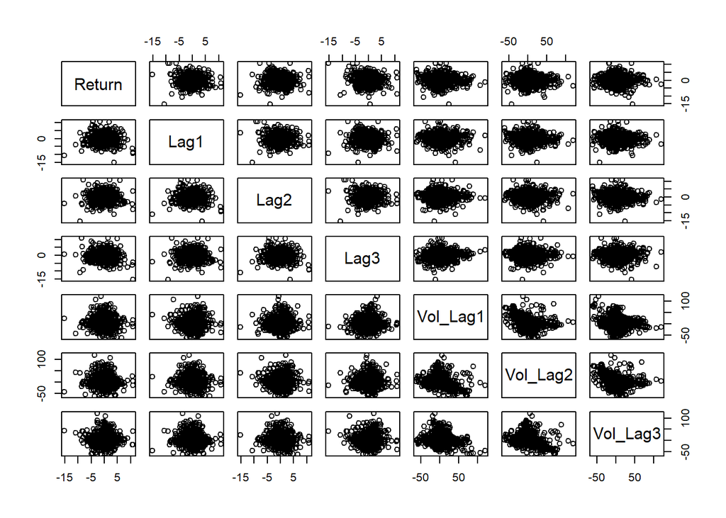

```r
pairs(~Return+Lag1+Lag2+Lag3+Vol_Lag1+Vol_Lag2+Vol_Lag3)
```

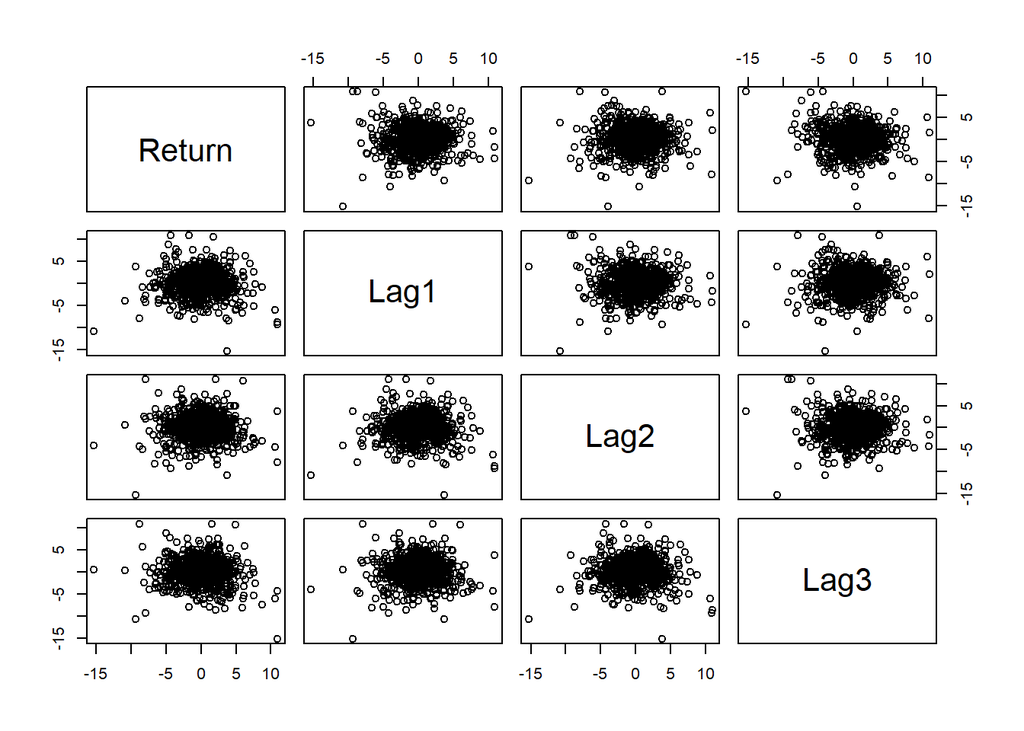

```r
pairs(~Return+Lag1+Lag2+Lag3)
```

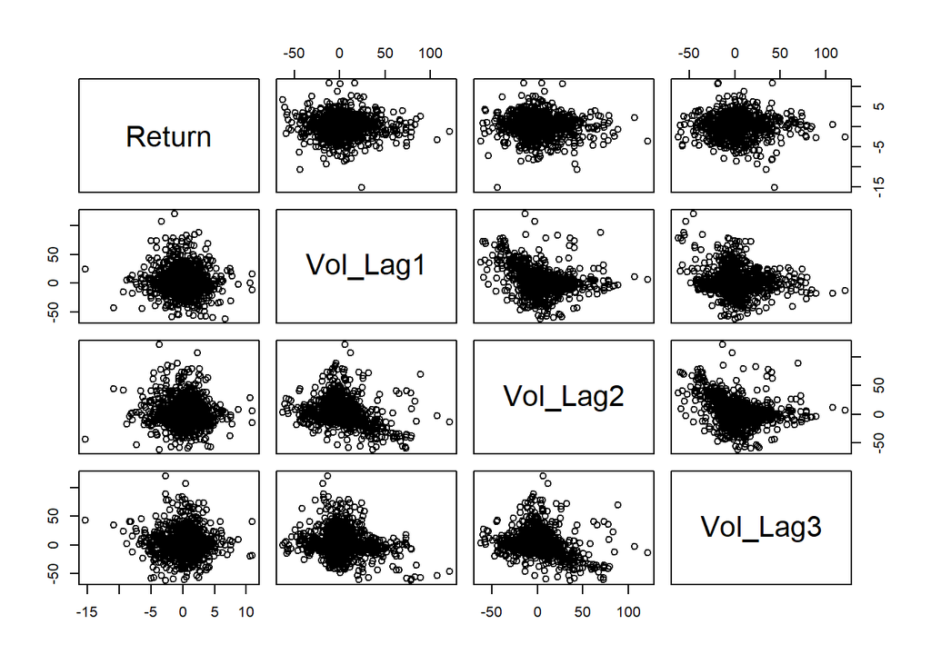

```r
pairs(~Return+Vol_Lag1+Vol_Lag2+Vol_Lag3)
```

The scatterplot matrices do not show any clear relationships between Return and the other variables. They do show potential quadratic relationships between Vol_Lag1 and Vol_Lag2 as well as Vol_Lag2 and Vol_Lag3.

We fit a linear model to the full dataset with Return as the response and the Lag variables along with some interaction terms as predictors.

```r
linear_fit1 = lm(Return~Lag1+Lag2+Lag3+Vol_Lag1+Vol_Lag2+Vol_Lag3+Lag1:Vol_Lag1+Lag1:Lag2+Vol_Lag1:Vol_Lag2,data=nasdaq)
summary(linear_fit1)
```

```
##
## Call:
## lm(formula = Return ~ Lag1 + Lag2 + Lag3 + Vol_Lag1 + Vol_Lag2 +
##     Vol_Lag3 + Lag1:Vol_Lag1 + Lag1:Lag2 + Vol_Lag1:Vol_Lag2,
##     data = nasdaq)
##
## Residuals:
##      Min       1Q   Median       3Q      Max
## -16.0075  -1.3582   0.1501   1.5920   9.9006
##
## Coefficients:
##                     Estimate Std. Error t value Pr(>|t|)
## (Intercept)        3.100e-01  9.280e-02   3.340  0.00087 ***
## Lag1              -1.956e-02  3.508e-02  -0.558  0.57725
## Lag2              -9.149e-03  3.286e-02  -0.278  0.78074
## Lag3              -7.195e-02  3.256e-02  -2.210  0.02736 *
## Vol_Lag1          -1.221e-02  4.233e-03  -2.884  0.00402 **
## Vol_Lag2          -1.207e-02  4.471e-03  -2.700  0.00705 **
## Vol_Lag3          -8.739e-03  4.124e-03  -2.119  0.03434 *
## Lag1:Vol_Lag1      2.130e-03  1.281e-03   1.663  0.09667 .
## Lag1:Lag2          2.248e-02  8.318e-03   2.702  0.00701 **
## Vol_Lag1:Vol_Lag2  6.114e-05  1.515e-04   0.404  0.68656
## ---
## Signif. codes:  0 '***' 0.001 '**' 0.01 '*' 0.05 '.' 0.1 ' ' 1
##
## Residual standard error: 2.631 on 926 degrees of freedom
## Multiple R-squared:  0.02727,    Adjusted R-squared:  0.01781
## F-statistic: 2.884 on 9 and 926 DF,  p-value: 0.002291
```

```r
summary(linear_fit1)$sigma/sd(nasdaq$Return)  #RSE as a percent of return std. dev.
```

```
## [1] 0.9910541
```

The F-test indicates that the model is statistically significant overall. The predictors Lag3, Vol_Lag1, Vol_Lag2, Vol_lag3, and Lag1:Lag2 are statistically significant. The adjusted R-squared value is very low – – only ~1.8% of the variance in the response is explained by the predictors after accounting for model size. Also, the residual standard error (RSE) is 2.63, meaning that the average error in predicted return is 2.63. This is ~99% of the Return standard deviation – – a large error. The adjusted R-squared and RSE both indicate a poor fitting model.

We fit a linear model with only the statistically significant predictors. Also, we perform a nested F-test to compare the full model with the submodel.

```r
linear_fit2 = lm(Return~Lag3+Vol_Lag1+Vol_Lag2+Vol_Lag3+Lag1:Lag2,data=nasdaq)
summary(linear_fit2)
```

```
##
## Call:
## lm(formula = Return ~ Lag3 + Vol_Lag1 + Vol_Lag2 + Vol_Lag3 +
##     Lag1:Lag2, data = nasdaq)
##
## Residuals:
##      Min       1Q   Median       3Q      Max
## -16.3355  -1.4206   0.1608   1.5934  10.3306
##
## Coefficients:
##              Estimate Std. Error t value Pr(>|t|)
## (Intercept)  0.288206   0.089097   3.235  0.00126 **
## Lag3        -0.069788   0.032473  -2.149  0.03189 *
## Vol_Lag1    -0.011616   0.004113  -2.824  0.00484 **
## Vol_Lag2    -0.011379   0.004181  -2.722  0.00662 **
## Vol_Lag3    -0.008361   0.004085  -2.047  0.04098 *
## Lag1:Lag2    0.021892   0.007914   2.766  0.00578 **
## ---
## Signif. codes:  0 '***' 0.001 '**' 0.01 '*' 0.05 '.' 0.1 ' ' 1
##
## Residual standard error: 2.63 on 930 degrees of freedom
## Multiple R-squared:  0.02422,    Adjusted R-squared:  0.01898
## F-statistic: 4.617 on 5 and 930 DF,  p-value: 0.0003622
```

```r
anova(linear_fit2,linear_fit1)
```

```
## Analysis of Variance Table
##
## Model 1: Return ~ Lag3 + Vol_Lag1 + Vol_Lag2 + Vol_Lag3 + Lag1:Lag2
## Model 2: Return ~ Lag1 + Lag2 + Lag3 + Vol_Lag1 + Vol_Lag2 + Vol_Lag3 +
##     Lag1:Vol_Lag1 + Lag1:Lag2 + Vol_Lag1:Vol_Lag2
##   Res.Df    RSS Df Sum of Sq      F Pr(>F)
## 1    930 6430.8
## 2    926 6410.7  4    20.065 0.7246 0.5752
```

The submodel has the same RSE as the full model and a slightly higher adjusted R-squared. The nested F-test indicates that the full model is not superior to the submodel.

Next, we perform backward elimination and forward addition with AIC as the information criteria.

```r
m_empty = lm(Return~1, data=nasdaq)
m_full = lm(Return~Lag1+Lag2+Lag3+Vol_Lag1+Vol_Lag2+Vol_Lag3+Lag1:Vol_Lag1+Lag1:Lag2+Vol_Lag1:Vol_Lag2,data=nasdaq)

#Backward Elimination
m_bwd = step(m_full, scope = list(lower = m_empty$formula, upper = m_full$formula), direction = "backward", k = 2, trace = 0)
m_bwd$coefficients
```

```
##   (Intercept)          Lag1          Lag2          Lag3      Vol_Lag1
##   0.301134818  -0.019627584  -0.009083436  -0.072163105  -0.012534730
##      Vol_Lag2      Vol_Lag3 Lag1:Vol_Lag1     Lag1:Lag2
##  -0.011460649  -0.008782347   0.002106325   0.022792839
```

```r
#Forward Addition
m_fwd = step(m_empty, scope = list(lower = m_empty$formula, upper = m_full$formula), direction = "forward", k = 2, trace = 0)
m_fwd$coefficients
```

```
## (Intercept)
##   0.1949223
```

Backward elimination results in a model with many predictors (some of which are not statistically significant) while forward addition results in a model with only the intercept (mean of the response).

For the final linear model, we choose linear_fit2 because all of its predictors are statistically significant.

#### Model Diagnostics

We now perform model diagnostics to check the assumptions of linear regression.

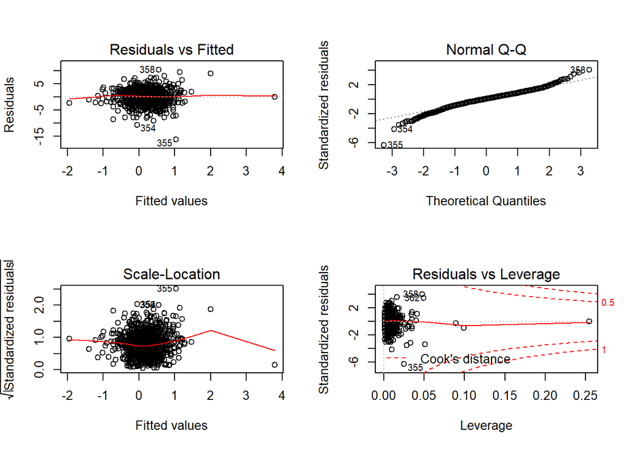

```r
par(mfrow=c(2,2))
plot(linear_fit2)
library(faraway)
```

```r
vif(linear_fit2)
```

```
##      Lag3  Vol_Lag1  Vol_Lag2  Vol_Lag3 Lag1:Lag2
##  1.009782  1.186671  1.226652  1.172767  1.017556
```

The assumptions about the model errors appear to be valid with the linear_fit2 model. Also, there are no multicollinearity problems as the VIFs are all near one.

#### Estimating the test error

We perform 10-fold cross-validation 50 times on linear_fit2. We then compute the mean and standard deviation of the 50 root mean squared errors.

```r
library(boot)
linear_fit2 = glm(Return~Lag3+Vol_Lag1+Vol_Lag2+Vol_Lag3+Lag1:Lag2,data=nasdaq)  #Fit linear_fit2 using glm() function so that we can use the cv.glm() function on it
cv_error = rep(0,50)
set.seed(2)
for (i in 1:50){
  cv_error[i] = cv.glm(nasdaq, linear_fit2, K = 10)$delta[1]
}
rmse = sqrt(cv_error)  #Convert to root mean squared error (RMSE)
mean_error = mean(rmse)
sd_error = sd(rmse)

mean_error  #Mean RMSE
```

```
## [1] 2.650197
```

```r
sd_error   #Standard deviation of RMSEs
```

```
## [1] 0.00611688
```

```r
mean_error/sd(nasdaq$Return)
```

```
## [1] 0.9982239
```

The mean RMSE is 2.65 and the standard deviation is 0.006. The mean RMSE is ~99.8% of the Return standard deviation.

We also compute RMSE for a test set containing a random sample of 200 observations.

```r
#Split data into training and test sets
set.seed(2)
test = sample(1:nrow(nasdaq), 200)
train = nasdaq[-test,]

#Fit linear_fit2 on training set and compute test set RMSE
linear_fit2 = lm(Return~Lag3+Vol_Lag1+Vol_Lag2+Vol_Lag3+Lag1:Lag2,data=train)
pred_test = predict(linear_fit2, newdata=nasdaq[test,], type='response')
rmse_test = sqrt(mean((nasdaq[test,'Return']-pred_test)^2))
rmse_test  #Test set RMSE
```

```
## [1] 2.529308
```

```r
rmse_test/sd(nasdaq$Return)
```

```
## [1] 0.9526898
```

The RMSE is ~2.53, which is ~95% of the Return standard deviation. This error and the mean 10-fold CV error are both very large and this suggests that the model is not useful.

Finally, to further gauge the utility of the model, we compute the RMSE when the mean training data return is predicted for all the test set observations.

```r
mean_pred = rep(mean(train[,'Return']), 200)
rmse_test0 = sqrt(mean((nasdaq[test,'Return']-mean_pred)^2))
rmse_test0
```

```
## [1] 2.548371
```

The RMSE is ~2.55. This means that the linear regression model’s predictive ability is essentially the same as simply using the mean training return as the predicted response.

### Regression Trees

We fit a regression tree to the training data and plot the tree.

```r
library(tree)
regression_tree = tree(Return~Lag1+Lag2+Lag3+Vol_Lag1+Vol_Lag2+Vol_Lag3, data=train)
summary(regression_tree)
```

```
##
## Regression tree:
## tree(formula = Return ~ Lag1 + Lag2 + Lag3 + Vol_Lag1 + Vol_Lag2 +
##     Vol_Lag3, data = train)
## Variables actually used in tree construction:
## [1] "Lag3"     "Vol_Lag1" "Vol_Lag2" "Lag1"     "Vol_Lag3"
## Number of terminal nodes:  8
## Residual mean deviance:  6.505 = 4736 / 728
## Distribution of residuals:
##      Min.   1st Qu.    Median      Mean   3rd Qu.      Max.
## -15.59000  -1.35100   0.09879   0.00000   1.54900  10.63000
```

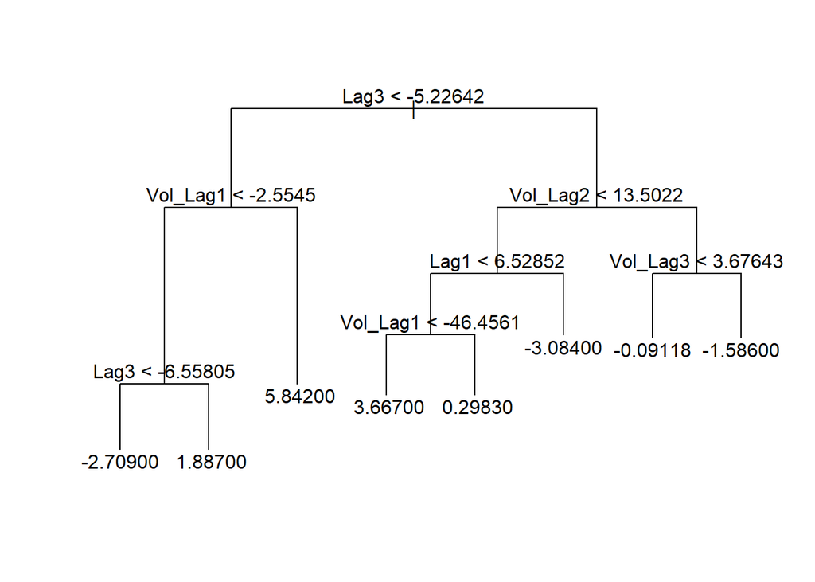

```r
plot(regression_tree)
text(regression_tree,pretty=0)
```

The tree uses the predictors Lag1, Lag3, and the three Vol_Lags. It has 8 terminal nodes and its training mean squared error (MSE) is 6.5.

#### Determining the best tree size and estimating the test error

We perform 10-fold CV 50 times on the regression tree and we extract the best tree size (the size corresponding to the lowest CV error) on each iteration. We then compute the mean and standard deviation of the 50 optimal tree sizes.

```r
best_sizes = rep(0,50)
set.seed(2)
for (i in 1:50){
  cv_tree = cv.tree(regression_tree,FUN=prune.tree,K=10)
  best_sizes[i] = cv_tree$size[which.min(cv_tree$dev)]
}

best_size_mean = mean(best_sizes)
best_size_sd = sd(best_sizes)
best_size_mean  #Mean optimal tree size
```

```
## [1] 1
```

```r
best_size_sd   #Standard deviation of optimal tree sizes
```

```
## [1] 0
```

The mean of the 50 optimal tree sizes is 1 and the standard deviation is 0, which means that the best tree size was 1 for all 50 iterations of 10-fold CV.

The tree with 1 terminal node means that it will always predict the mean training return, no matter the test observation. So the test set RMSE for this tree will be ~2.55, the same as the previous RMSE computation. The regression tree is therefore not valuable for predicting weekly Nasdaq returns.

### Logistic Regression

We create several boxplots to examine the associations between Direction (the response) and the Lags, Vol_Lags, and Lags*Vol_Lags.

```r
contrasts(nasdaq$Direction)  #Direction is coded so that 0 is 'Down' and 1 is 'Up'
```

```
##      Up
## Down  0
## Up    1
```

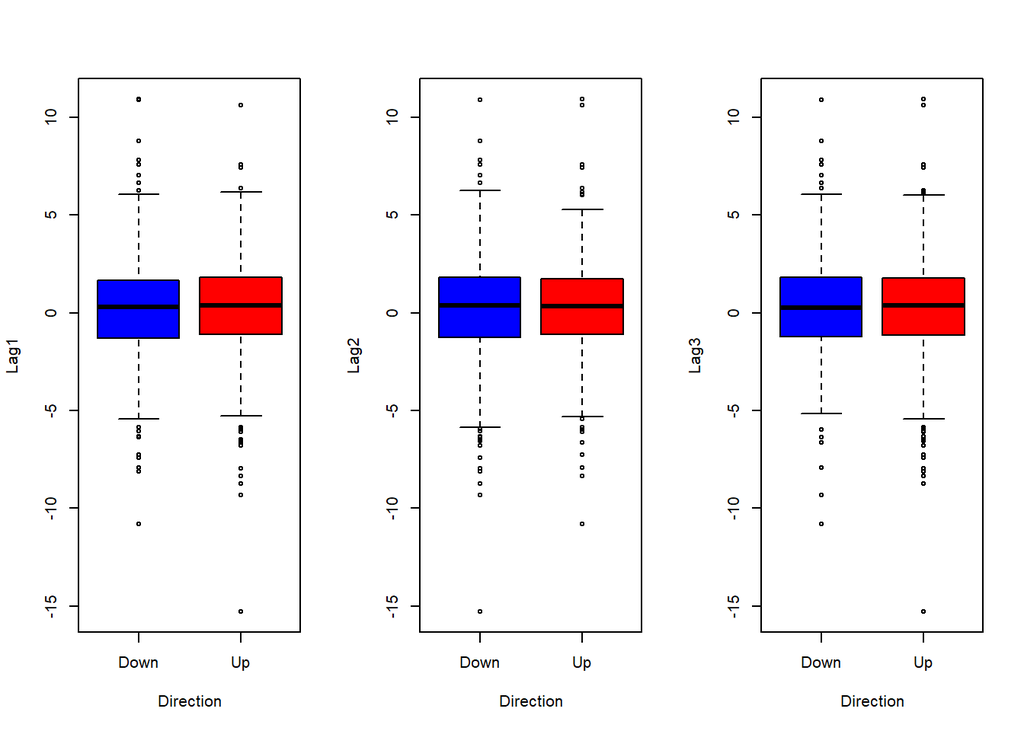

```r
par(mfrow = c(1, 3))

plot(nasdaq$Lag1 ~ nasdaq$Direction, col = c(4, 2), xlab = "Direction", ylab = "Lag1")
plot(nasdaq$Lag2 ~ nasdaq$Direction, col = c(4, 2), xlab = "Direction", ylab = "Lag2")
plot(nasdaq$Lag3 ~ nasdaq$Direction, col = c(4, 2), xlab = "Direction", ylab = "Lag3")
```

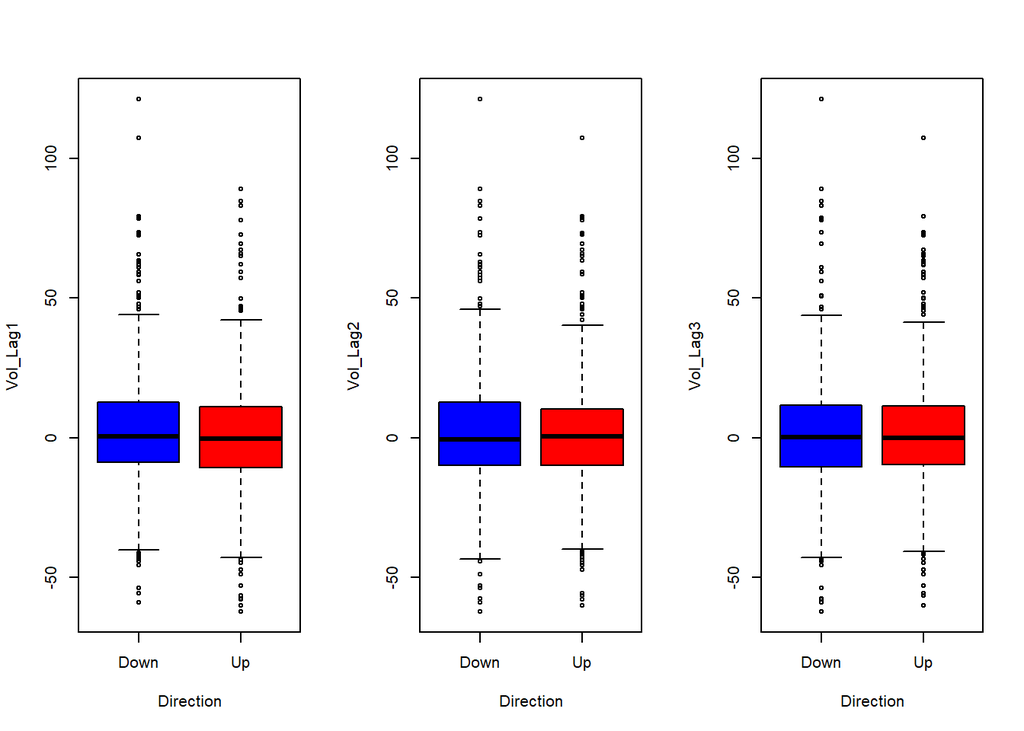

```r
plot(nasdaq$Vol_Lag1 ~ nasdaq$Direction, col = c(4, 2), xlab = "Direction", ylab = "Vol_Lag1")
plot(nasdaq$Vol_Lag2 ~ nasdaq$Direction, col = c(4, 2), xlab = "Direction", ylab = "Vol_Lag2")
plot(nasdaq$Vol_Lag3 ~ nasdaq$Direction, col = c(4, 2), xlab = "Direction", ylab = "Vol_Lag3")
```

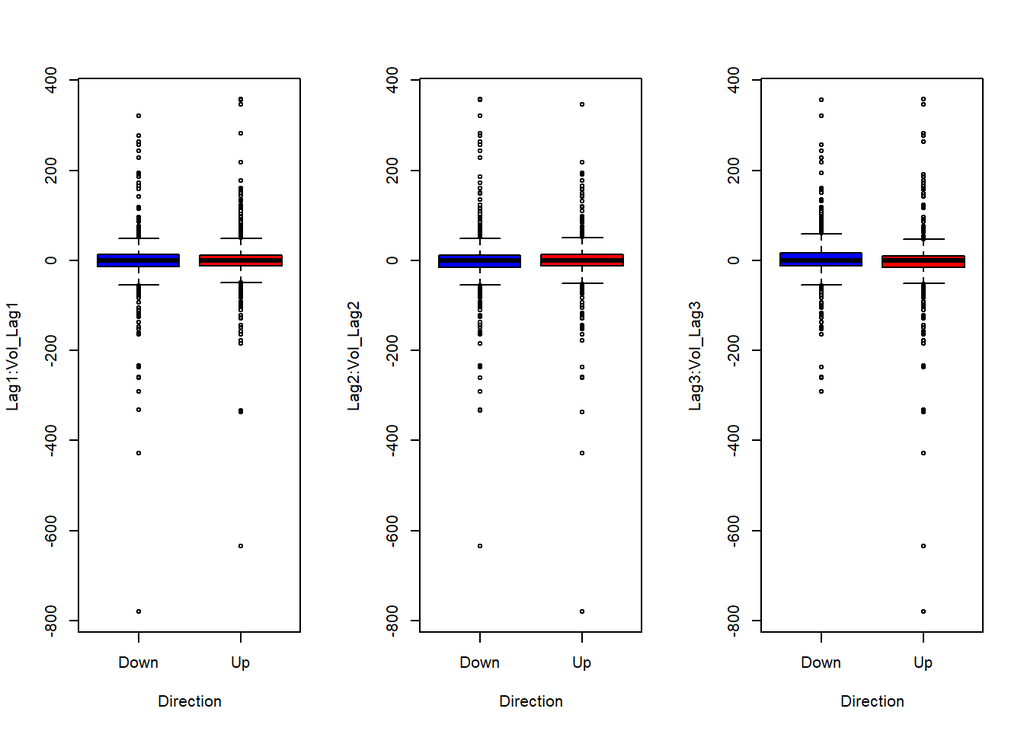

```r
plot(nasdaq$Vol_Lag1*nasdaq$Lag1 ~ nasdaq$Direction, col = c(4, 2), xlab = "Direction", ylab = "Lag1:Vol_Lag1")
plot(nasdaq$Vol_Lag2*nasdaq$Lag2 ~ nasdaq$Direction, col = c(4, 2), xlab = "Direction", ylab = "Lag2:Vol_Lag2")
plot(nasdaq$Vol_Lag3*nasdaq$Lag3 ~ nasdaq$Direction, col = c(4, 2), xlab = "Direction", ylab = "Lag3:Vol_Lag3")
```

The boxplots show no clear relationships between the predictors and the response.

We perform backward elimination and forward addition with AIC as the information criteria.

```r
logit.full = glm(Direction ~ Lag1 + Lag2 + Lag3 + Vol_Lag1 + Vol_Lag2 + Vol_Lag3 + Lag1:Vol_Lag1 + Lag2:Vol_Lag2 + Lag3:Vol_Lag3, data = nasdaq, family = "binomial")

logit.empty = glm(Direction ~ 1, data = nasdaq, family = "binomial")

#Backward Elimination
logit.bwd = step(logit.full, scope = list(lower = logit.empty$formula, upper = logit.full$formula), direction = "backward", k = 2, trace = 0)
summary(logit.bwd)
```

```
##
## Call:
## glm(formula = Direction ~ Vol_Lag1, family = "binomial", data = nasdaq)
##
## Deviance Residuals:
##    Min      1Q  Median      3Q     Max
## -1.439  -1.276   1.021   1.079   1.303
##
## Coefficients:
##              Estimate Std. Error z value Pr(>|z|)
## (Intercept)  0.243195   0.066425   3.661 0.000251 ***
## Vol_Lag1    -0.005992   0.002908  -2.061 0.039341 *
## ---
## Signif. codes:  0 '***' 0.001 '**' 0.01 '*' 0.05 '.' 0.1 ' ' 1
##
## (Dispersion parameter for binomial family taken to be 1)
##
##     Null deviance: 1285.5  on 935  degrees of freedom
## Residual deviance: 1281.3  on 934  degrees of freedom
## AIC: 1285.3
##
## Number of Fisher Scoring iterations: 4
```

```r
#Forward Addition
logit.fwd = step(logit.empty, scope = list(lower = logit.empty$formula, upper = logit.full$formula), direction = "forward", k = 2, trace = 0)
summary(logit.fwd)
```

```
##
## Call:
## glm(formula = Direction ~ Vol_Lag1, family = "binomial", data = nasdaq)
##
## Deviance Residuals:
##    Min      1Q  Median      3Q     Max
## -1.439  -1.276   1.021   1.079   1.303
##
## Coefficients:
##              Estimate Std. Error z value Pr(>|z|)
## (Intercept)  0.243195   0.066425   3.661 0.000251 ***
## Vol_Lag1    -0.005992   0.002908  -2.061 0.039341 *
## ---
## Signif. codes:  0 '***' 0.001 '**' 0.01 '*' 0.05 '.' 0.1 ' ' 1
##
## (Dispersion parameter for binomial family taken to be 1)
##
##     Null deviance: 1285.5  on 935  degrees of freedom
## Residual deviance: 1281.3  on 934  degrees of freedom
## AIC: 1285.3
##
## Number of Fisher Scoring iterations: 4
```

Backward elimination results in a logistic regression model with predictor Vol_Lag1 and AIC = 1285. Forward addition results in the same model.

#### Estimating the test error rate

We perform LOOCV on the logistic regression model selected by both forward addition and backward elimination.

```r
loocv = cv.glm(nasdaq, logit.bwd, cost = function(r, pi = 0) mean(abs(r-pi) > 0.5))$delta[1]  #The cost argument is necessary to get the classification error rate rather than the mean squared error
loocv
```

```
## [1] 0.4358974
```

The LOOCV classification error rate is ~43.6%.

We also perform 10-fold CV on the model.

```r
set.seed(2)
kfold = cv.glm(nasdaq, logit.bwd, cost = function(r, pi = 0) mean(abs(r-pi) > 0.5), K = 10)$delta[1]
kfold
```

```
## [1] 0.4358974
```

The 10-fold CV classification error rate is also ~43.6%.

This error rate means that the logit.bwd model incorrectly predicted the direction of the Nasdaq approximately 43.6% of the time.

We refit the model using the training data and then test it using the test set.

```r
logit_train = glm(Direction~Vol_Lag1, data = train, family = 'binomial')
yprobs.test = predict(logit_train, newdata=nasdaq[test,], type='response')
ypreds.test = rep('Down',nrow(nasdaq[test,]))
ypreds.test[yprobs.test>.5] = 'Up'
yobs.test = nasdaq[test,'Direction']
table(ypreds.test,yobs.test)
```

```
##            yobs.test
## ypreds.test Down  Up
##        Down    9  14
##        Up     75 102
```

```r
mean(ypreds.test != yobs.test)  #Test set error rate
```

```
## [1] 0.445
```

```r
mean(ypreds.test == yobs.test)  #Test set accuracy rate
```

```
## [1] 0.555
```

```r
9/(9+14)
```

```
## [1] 0.3913043
```

```r
102/(102+75)
```

```
## [1] 0.5762712
```

The test set classification error rate is 44.5% and the accuracy rate is 55.5%. When the model predicted the Nasdaq to go down, it was right only ~39% of the time, and when the model predicted the Nasdaq to go up, it was right ~57.6% of the time.

We compute the percent of weeks (in the full dataset and in the test set) that the Nasdaq Composite Index went up in order to put the predictive ability of the model in context.

```r
mean(nasdaq$Direction == 'Up')
```

```
## [1] 0.5566239
```

```r
mean(nasdaq[test,'Direction'] == 'Up')
```

```
## [1] 0.58
```

In the full data set, the Nasdaq went up ~55.7% of the weeks, and in the test set, the Nasdaq went up 58% of the weeks. Using LOOCV and 10-fold CV, our model had an accuracy rate of ~56.4%, and using the test set, it had an accuracy rate of 55.5%. This means that by just simply predicting that the Nasdaq will go up every week, you would have an accuracy rate around the same as (or better than) if you were using the model.

### Classification Trees

We fit a classification tree to the training data using all the Lag and Vol_Lag predictors and using Gini index as the splitting criteria.

```r
classification_tree = tree(Direction~ Lag1 + Lag2 + Lag3 + Vol_Lag1 + Vol_Lag2 + Vol_Lag3, split = "gini", data = train)
summary(classification_tree)
```

```
##
## Classification tree:
## tree(formula = Direction ~ Lag1 + Lag2 + Lag3 + Vol_Lag1 + Vol_Lag2 +
##     Vol_Lag3, data = train, split = "gini")
## Number of terminal nodes:  106
## Residual mean deviance:  0.809 = 509.6 / 630
## Misclassification error rate: 0.1875 = 138 / 736
```

The tree has 106 terminal nodes and a training classification error rate of ~18.8%.

We plot the tree without labels to see how complex it is.

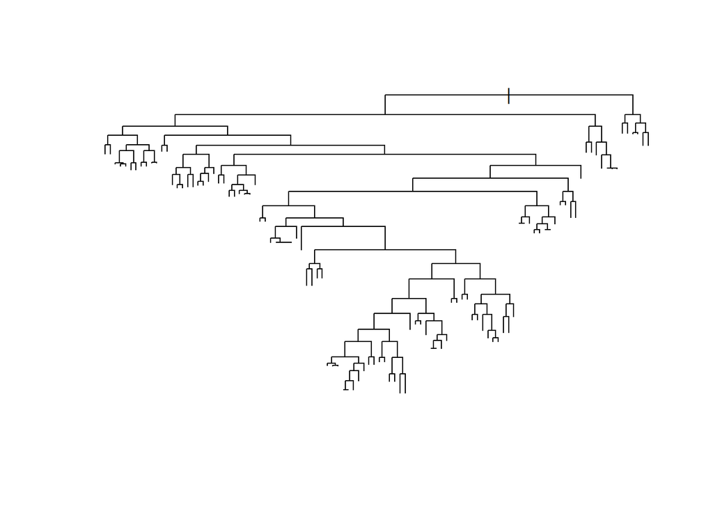

```r
par(mfrow=c(1,1))
plot(classification_tree)
```

#### Estimating the test error rate of the unpruned tree

We compute the test set error and accuracy rates.

```r
set.seed(2)
tree_pred = predict(classification_tree, newdata = nasdaq[test,], type = 'class')
table(tree_pred, yobs.test)
```

```
##          yobs.test
## tree_pred Down Up
##      Down   36 52
##      Up     48 64
```

```r
mean(tree_pred != yobs.test)
```

```
## [1] 0.5
```

```r
mean(tree_pred == yobs.test)
```

```
## [1] 0.5
```

The test set classification error rate is 50% and the accuracy rate is 50%.

#### Pruning the tree

```r
pruned_tree = prune.tree(classification_tree, best = 5, method = "misclass")
summary(pruned_tree)
```

```
##
## Classification tree:
## snip.tree(tree = classification_tree, nodes = c(18L, 77L, 8L,
## 3L, 76L, 5L, 79L, 78L))
## Variables actually used in tree construction:
## [1] "Vol_Lag1" "Lag3"     "Lag1"
## Number of terminal nodes:  8
## Residual mean deviance:  1.327 = 965.7 / 728
## Misclassification error rate: 0.3736 = 275 / 736
```

The pruned tree uses the predictors Vol_Lag1, Lag3, and Lag1 and has a training classification error rate of ~37.4%.

We plot the pruned tree.

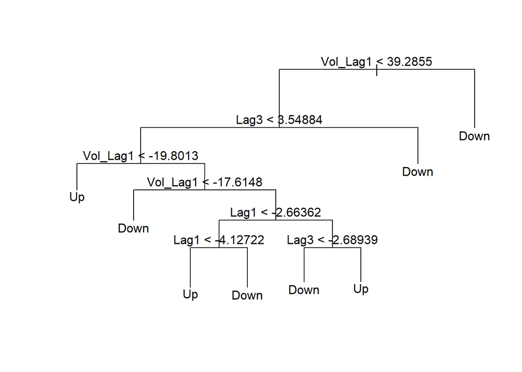

```r
plot(pruned_tree)
text(pruned_tree, pretty = 0)
```

#### Estimating the test error rate of the pruned tree

We compute the test set error and accuracy rates.

```r
set.seed(2)
pruned_tree_pred = predict(pruned_tree, newdata = nasdaq[test,], type = 'class')
table(pruned_tree_pred, yobs.test)
```

```
##                 yobs.test
## pruned_tree_pred Down Up
##             Down   28 31
##             Up     56 85
```

```r
mean(pruned_tree_pred != yobs.test)
```

```
## [1] 0.435
```

```r
mean(pruned_tree_pred == yobs.test)
```

```
## [1] 0.565
```

The test set classification error rate is 43.5% and the accuracy rate is 56.5%.

The pruned tree has better predictive ability than the unpruned tree but performs similarly to the logistic regression model.

## Conclusion

In this analysis, we utilized both regression and classification to predict the weekly return and direction of the Nasdaq Composite Index. The data we used spanned the past 18 years, during which there was a recession as well as periods of economic expansion. The results from both the regression and classification models lead to the same conclusion, which is that none of the models would be useful for predicting the magnitude or direction of weekly Nasdaq returns.

The basis for this conclusion are the large estimated test errors. The linear regression model and pruned regression tree result in errors that are nearly as large as the return standard deviation and are comparable to the error you get when simply predicting the mean training return for every test set observation. The logistic regression model and pruned classification tree have error rates that are similar to the error rate you would get by simply predicting that the Nasdaq will go up every week. Therefore, these models provide no advantage over rudimentary methods and would be of no use to stock traders.